# Project

Group 5

2022-04-27

```r
library(dplyr)
library(caret)
```

```r
library(scales)
library(ggplot2)
library(gridExtra)
```

# Loading the data set and data set summary

```r
parkinsons <- read.csv('parkinsons_updrs.csv', stringsAsFactors = FALSE)

head(parkinsons)
```

```
##   subject. age sex test_time motor_UPDRS total_UPDRS Jitter... Jitter.Abs.
## 1        1  72   0    5.6431      28.199      34.398   0.00662   3.380e-05
## 2        1  72   0   12.6660      28.447      34.894   0.00300   1.680e-05
## 3        1  72   0   19.6810      28.695      35.389   0.00481   2.462e-05
## 4        1  72   0   25.6470      28.905      35.810   0.00528   2.657e-05
## 5        1  72   0   33.6420      29.187      36.375   0.00335   2.014e-05
## 6        1  72   0   40.6520      29.435      36.870   0.00353   2.290e-05
##   Jitter.RAP Jitter.PPQ5 Jitter.DDP Shimmer Shimmer.dB. Shimmer.APQ3
## 1    0.00401     0.00317    0.01204 0.02565       0.230      0.01438
## 2    0.00132     0.00150    0.00395 0.02024       0.179      0.00994
## 3    0.00205     0.00208    0.00616 0.01675       0.181      0.00734
## 4    0.00191     0.00264    0.00573 0.02309       0.327      0.01106
## 5    0.00093     0.00130    0.00278 0.01703       0.176      0.00679
## 6    0.00119     0.00159    0.00357 0.02227       0.214      0.01006
##   Shimmer.APQ5 Shimmer.APQ11 Shimmer.DDA      NHR    HNR    RPDE     DFA
## 1      0.01309       0.01662     0.04314 0.014290 21.640 0.41888 0.54842
## 2      0.01072       0.01689     0.02982 0.011112 27.183 0.43493 0.56477
## 3      0.00844       0.01458     0.02202 0.020220 23.047 0.46222 0.54405
## 4      0.01265       0.01963     0.03317 0.027837 24.445 0.48730 0.57794
## 5      0.00929       0.01819     0.02036 0.011625 26.126 0.47188 0.56122
## 6      0.01337       0.02263     0.03019 0.009438 22.946 0.53949 0.57243
##       PPE
## 1 0.16006
## 2 0.10810
## 3 0.21014
## 4 0.33277
## 5 0.19361
## 6 0.19500
```

```r
summary(parkinsons)
```

```
##     subject.          age            sex           test_time
##  Min.   : 1.00   Min.   :36.0   Min.   :0.0000   Min.   : -4.263
##  1st Qu.:10.00   1st Qu.:58.0   1st Qu.:0.0000   1st Qu.: 46.847
##  Median :22.00   Median :65.0   Median :0.0000   Median : 91.523
##  Mean   :21.49   Mean   :64.8   Mean   :0.3178   Mean   : 92.864
##  3rd Qu.:33.00   3rd Qu.:72.0   3rd Qu.:1.0000   3rd Qu.:138.445
##  Max.   :42.00   Max.   :85.0   Max.   :1.0000   Max.   :215.490
##   motor_UPDRS      total_UPDRS      Jitter...         Jitter.Abs.
##  Min.   : 5.038   Min.   : 7.00   Min.   :0.000830   Min.   :2.250e-06
##  1st Qu.:15.000   1st Qu.:21.37   1st Qu.:0.003580   1st Qu.:2.244e-05
##  Median :20.871   Median :27.58   Median :0.004900   Median :3.453e-05
##  Mean   :21.296   Mean   :29.02   Mean   :0.006154   Mean   :4.403e-05
##  3rd Qu.:27.596   3rd Qu.:36.40   3rd Qu.:0.006800   3rd Qu.:5.333e-05
##  Max.   :39.511   Max.   :54.99   Max.   :0.099990   Max.   :4.456e-04
##    Jitter.RAP        Jitter.PPQ5         Jitter.DDP          Shimmer
##  Min.   :0.000330   Min.   :0.000430   Min.   :0.000980   Min.   :0.00306
##  1st Qu.:0.001580   1st Qu.:0.001820   1st Qu.:0.004730   1st Qu.:0.01912
##  Median :0.002250   Median :0.002490   Median :0.006750   Median :0.02751
##  Mean   :0.002987   Mean   :0.003277   Mean   :0.008962   Mean   :0.03404
##  3rd Qu.:0.003290   3rd Qu.:0.003460   3rd Qu.:0.009870   3rd Qu.:0.03975
##  Max.   :0.057540   Max.   :0.069560   Max.   :0.172630   Max.   :0.26863
##   Shimmer.dB.     Shimmer.APQ3      Shimmer.APQ5     Shimmer.APQ11
##  Min.   :0.026   Min.   :0.00161   Min.   :0.00194   Min.   :0.00249
##  1st Qu.:0.175   1st Qu.:0.00928   1st Qu.:0.01079   1st Qu.:0.01566
##  Median :0.253   Median :0.01370   Median :0.01594   Median :0.02271
##  Mean   :0.311   Mean   :0.01716   Mean   :0.02014   Mean   :0.02748
##  3rd Qu.:0.365   3rd Qu.:0.02057   3rd Qu.:0.02375   3rd Qu.:0.03272
##  Max.   :2.107   Max.   :0.16267   Max.   :0.16702   Max.   :0.27546
##   Shimmer.DDA           NHR                HNR              RPDE
##  Min.   :0.00484   Min.   :0.000286   Min.   : 1.659   Min.   :0.1510
##  1st Qu.:0.02783   1st Qu.:0.010955   1st Qu.:19.406   1st Qu.:0.4698
##  Median :0.04111   Median :0.018448   Median :21.920   Median :0.5423
##  Mean   :0.05147   Mean   :0.032120   Mean   :21.680   Mean   :0.5415
##  3rd Qu.:0.06173   3rd Qu.:0.031463   3rd Qu.:24.444   3rd Qu.:0.6140
##  Max.   :0.48802   Max.   :0.748260   Max.   :37.875   Max.   :0.9661
##       DFA              PPE
##  Min.   :0.5140   Min.   :0.02198
##  1st Qu.:0.5962   1st Qu.:0.15634
##  Median :0.6436   Median :0.20550
##  Mean   :0.6532   Mean   :0.21959
##  3rd Qu.:0.7113   3rd Qu.:0.26449
##  Max.   :0.8656   Max.   :0.73173
```

# Explanation of Attributes

**Subject number** : Integer that uniquely identifies each subject

**Subject Age**

**Subject gender** ‘0’ - male, ‘1’ - female

**Test time** - Time since recruitment into the trial. The integer part is the number of days since recruitment.

**UPDRS**: This is a clinician’s scale for recording symptoms related to Parkinson’s disease. The UPDRS metric consists of 44 sections, where each section addresses different symptoms in different parts of the body. Summing up these 44 sections gives rise to the total-UPDRS score, which spans the range 0-176, with 0 representing perfectly healthy individual and 176 total disability.

**Motor UPDRS** - Clinician’s motor UPDRS score, linearly interpolated - this forms sections 18-44 from the UPDRS sections

**Total_UPDRS** - Clinician’s total UPDRS score, linearly interpolated - this includes all 44 sections

**Jitter Percentage** - measure of variation in fundamental frequency

**Jitter (Absolute)** - measure of variation in fundamental frequency

**Jitter (RAP)** - measure of variation in fundamental frequency

**Jitter (PPQ5)** - measure of variation in fundamental frequency

**Jitter (DDP)** - measure of variation in fundamental frequency

**Shimmer** - measures of variation in amplitude

**Shimmer(dB)**- measure of variation in amplitude

**Shimmer:APQ3**- measure of variation in amplitude

**Shimmer:APQ5**- measure of variation in amplitude

**Shimmer:APQ11**- measure of variation in amplitude

**Shimmer:DDA**- measure of variation in amplitude

**NHR**: measures of ratio of noise to tonal components in the voice

**HNR**: measures of ratio of noise to tonal components in the voice

**RPDE** - A nonlinear dynamical complexity measure

**DFA** - Signal fractal scaling exponent

**PPE** - A Non-linear measure of fundamental frequency variation

```r
str(parkinsons)
```

```
## 'data.frame':    5875 obs. of  22 variables:
##  $ subject.     : int  1 1 1 1 1 1 1 1 1 1 ...
##  $ age          : int  72 72 72 72 72 72 72 72 72 72 ...
##  $ sex          : int  0 0 0 0 0 0 0 0 0 0 ...
##  $ test_time    : num  5.64 12.67 19.68 25.65 33.64 ...
##  $ motor_UPDRS  : num  28.2 28.4 28.7 28.9 29.2 ...
##  $ total_UPDRS  : num  34.4 34.9 35.4 35.8 36.4 ...
##  $ Jitter...    : num  0.00662 0.003 0.00481 0.00528 0.00335 0.00353 0.00422 0.00476 0.00432 0.00496 ...
##  $ Jitter.Abs.  : num  3.38e-05 1.68e-05 2.46e-05 2.66e-05 2.01e-05 ...
##  $ Jitter.RAP   : num  0.00401 0.00132 0.00205 0.00191 0.00093 0.00119 0.00212 0.00226 0.00156 0.00258 ...
##  $ Jitter.PPQ5  : num  0.00317 0.0015 0.00208 0.00264 0.0013 0.00159 0.00221 0.00259 0.00207 0.00253 ...
##  $ Jitter.DDP   : num  0.01204 0.00395 0.00616 0.00573 0.00278 ...
##  $ Shimmer      : num  0.0256 0.0202 0.0168 0.0231 0.017 ...
##  $ Shimmer.dB.  : num  0.23 0.179 0.181 0.327 0.176 0.214 0.445 0.212 0.371 0.31 ...
##  $ Shimmer.APQ3 : num  0.01438 0.00994 0.00734 0.01106 0.00679 ...
##  $ Shimmer.APQ5 : num  0.01309 0.01072 0.00844 0.01265 0.00929 ...
##  $ Shimmer.APQ11: num  0.0166 0.0169 0.0146 0.0196 0.0182 ...
##  $ Shimmer.DDA  : num  0.0431 0.0298 0.022 0.0332 0.0204 ...
##  $ NHR          : num  0.0143 0.0111 0.0202 0.0278 0.0116 ...
##  $ HNR          : num  21.6 27.2 23 24.4 26.1 ...
##  $ RPDE         : num  0.419 0.435 0.462 0.487 0.472 ...
##  $ DFA          : num  0.548 0.565 0.544 0.578 0.561 ...
##  $ PPE          : num  0.16 0.108 0.21 0.333 0.194 ...
```

Based on the minimum values we can see that for variable ‘test_time’ there are negative values. So we will remove the negative values from the column

```r
parkinsons <- parkinsons[parkinsons$test_time >=0, ]

summary(parkinsons)
```

```
##     subject.          age             sex           test_time
##  Min.   : 1.00   Min.   :36.00   Min.   :0.0000   Min.   :  0.3958
##  1st Qu.:10.00   1st Qu.:58.00   1st Qu.:0.0000   1st Qu.: 47.3355
##  Median :22.00   Median :65.00   Median :0.0000   Median : 91.7540
##  Mean   :21.46   Mean   :64.81   Mean   :0.3184   Mean   : 93.0615
##  3rd Qu.:33.00   3rd Qu.:72.00   3rd Qu.:1.0000   3rd Qu.:138.4600
##  Max.   :42.00   Max.   :85.00   Max.   :1.0000   Max.   :215.4900
##   motor_UPDRS      total_UPDRS      Jitter...         Jitter.Abs.
##  Min.   : 5.038   Min.   : 7.00   Min.   :0.000830   Min.   :2.250e-06
##  1st Qu.:15.000   1st Qu.:21.36   1st Qu.:0.003580   1st Qu.:2.242e-05
##  Median :20.871   Median :27.52   Median :0.004900   Median :3.453e-05
##  Mean   :21.290   Mean   :29.01   Mean   :0.006156   Mean   :4.403e-05
##  3rd Qu.:27.594   3rd Qu.:36.40   3rd Qu.:0.006800   3rd Qu.:5.334e-05
##  Max.   :39.511   Max.   :54.99   Max.   :0.099990   Max.   :4.456e-04
##    Jitter.RAP        Jitter.PPQ5         Jitter.DDP          Shimmer
##  Min.   :0.000330   Min.   :0.000430   Min.   :0.000980   Min.   :0.00306
##  1st Qu.:0.001580   1st Qu.:0.001825   1st Qu.:0.004730   1st Qu.:0.01911
##  Median :0.002250   Median :0.002490   Median :0.006750   Median :0.02753
##  Mean   :0.002988   Mean   :0.003278   Mean   :0.008965   Mean   :0.03404
##  3rd Qu.:0.003290   3rd Qu.:0.003470   3rd Qu.:0.009880   3rd Qu.:0.03977
##  Max.   :0.057540   Max.   :0.069560   Max.   :0.172630   Max.   :0.26863
##   Shimmer.dB.     Shimmer.APQ3      Shimmer.APQ5     Shimmer.APQ11
##  Min.   :0.026   Min.   :0.00161   Min.   :0.00194   Min.   :0.00249
##  1st Qu.:0.175   1st Qu.:0.00928   1st Qu.:0.01079   1st Qu.:0.01566
##  Median :0.253   Median :0.01370   Median :0.01594   Median :0.02271
##  Mean   :0.311   Mean   :0.01716   Mean   :0.02015   Mean   :0.02749
##  3rd Qu.:0.365   3rd Qu.:0.02060   3rd Qu.:0.02378   3rd Qu.:0.03272
##  Max.   :2.107   Max.   :0.16267   Max.   :0.16702   Max.   :0.27546
##   Shimmer.DDA           NHR                HNR              RPDE
##  Min.   :0.00484   Min.   :0.000286   Min.   : 1.659   Min.   :0.1510
##  1st Qu.:0.02783   1st Qu.:0.010953   1st Qu.:19.404   1st Qu.:0.4697
##  Median :0.04111   Median :0.018448   Median :21.917   Median :0.5423
##  Mean   :0.05147   Mean   :0.032126   Mean   :21.680   Mean   :0.5414
##  3rd Qu.:0.06180   3rd Qu.:0.031464   3rd Qu.:24.445   3rd Qu.:0.6140
##  Max.   :0.48802   Max.   :0.748260   Max.   :37.875   Max.   :0.9661
##       DFA              PPE
##  Min.   :0.5140   Min.   :0.02198
##  1st Qu.:0.5961   1st Qu.:0.15638
##  Median :0.6435   Median :0.20556
##  Mean   :0.6533   Mean   :0.21962
##  3rd Qu.:0.7115   3rd Qu.:0.26459
##  Max.   :0.8656   Max.   :0.73173
```

First let us check the number of male and female patients in the data.

```r
male <- nrow(subset(parkinsons, sex == 0))

female <- nrow(subset(parkinsons, sex == 1))

print(c(male, female))
```

```
## [1] 3996 1867
```

We can see there are 3996 male patient records and 1867 female patient records which implies the parkinsons disease is more prominent in males then females.

```r
#parkinsons$sex <- ifelse(parkinsons$sex == 0, "Male","Female")

#head(parkinsons)
```

```r
library(correlation)
#correlation::correlation(parkinsons,include_factors = FALSE, method = 'pearson')
```

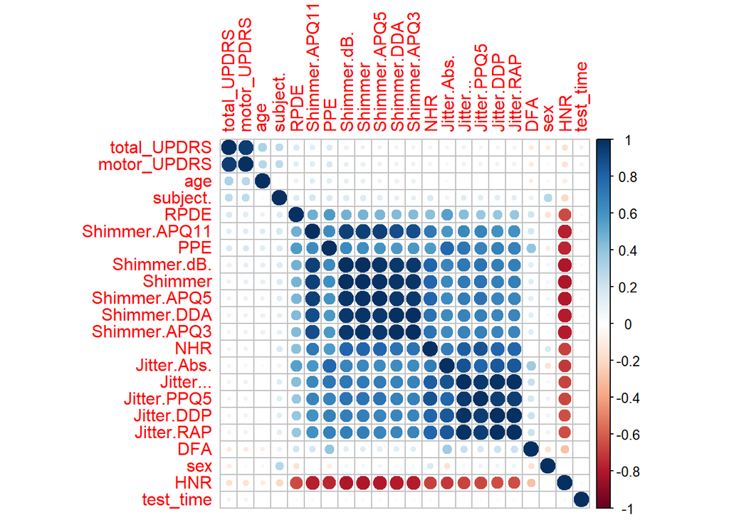

```r
library(corrplot)
corrplot(cor(parkinsons, method = 'pearson'), order = 'AOE')
```

We can observe there is high negative correlation between HNR and other variables.But this plot has too many variables and it is a bit cumbersome to understand. Let us plot the correlation for only those variables which have high significance.

```
##              Var1          Var2       Freq
## 366  Shimmer.APQ3   Shimmer.DDA  1.0000000
## 229    Jitter.RAP    Jitter.DDP  0.9999996
## 276       Shimmer   Shimmer.dB.  0.9923437
## 320       Shimmer  Shimmer.APQ5  0.9849898
## 227     Jitter...    Jitter.DDP  0.9841777
## 183     Jitter...    Jitter.RAP  0.9841749
## 298       Shimmer  Shimmer.APQ3  0.9797909
## 364       Shimmer   Shimmer.DDA  0.9797902
## 321   Shimmer.dB.  Shimmer.APQ5  0.9763786
## 205     Jitter...   Jitter.PPQ5  0.9682160
## 299   Shimmer.dB.  Shimmer.APQ3  0.9679894
## 365   Shimmer.dB.   Shimmer.DDA  0.9679889
## 367  Shimmer.APQ5   Shimmer.DDA  0.9627870
## 322  Shimmer.APQ3  Shimmer.APQ5  0.9627869
```

[output cut: 81 more lines]

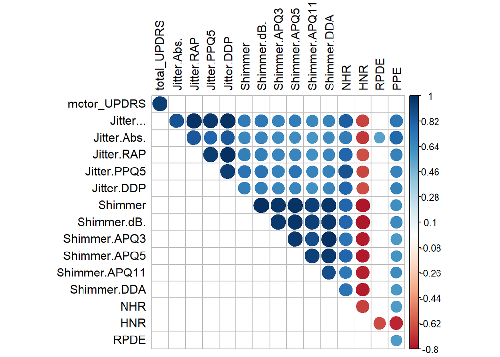

```r
corr_simple <- function(data = parkinsons, sig = 0.5){
  #convert data into numeric in order to run correlations
  #converting to factor first to keep the integrity of the data. This way each value will turn to numeric rather than NA
  park_cor <- parkinsons %>% mutate_if(is.character, as.factor)
  park_cor <- parkinsons %>% mutate_if(is.factor, as.numeric)

  #running correlation and dropping insignificant ones
  corr <- cor(park_cor)
  #droppping duplicates and correlations of 1
  corr[lower.tri(corr,diag = T)] <- NA
  corr[corr == 1] <- NA

  #turning into 3 column table and removing NA values
  corr <- as.data.frame(as.table(corr))
  corr <- na.omit(corr)

  #selecting significant values and sorting with highest correlation
  corr <- subset(corr, abs(Freq) > sig)
  corr <- corr[order(-abs(corr$Freq)),]

  #printing the table
  print(corr)

  #turning the correlation table back into matrix for plotting purposes
  mtx_corr <- reshape2::acast(corr,Var1~Var2, value.var = "Freq")

  corrplot(mtx_corr, is.corr = F, tl.col = "black", na.label = " ")
}

corr_simple()
```

We can now see the correlation plotted for the variables which have high significance.

From the correlation matrix we could see that motor_UPDRS and total_UPDRS are highly correlated(>0.8) and also from research we found out that motor_UPDRS is included in total_UPDRS and hence we are excluding motor_UPDRS from our analysis.

```r
#Removing motor_UPDRS

parkinsons <- select(parkinsons,-c(5))

#head(parkinsons)
```

[figure not shown]

```r
# boxplot for total UPDRS by different subjects
library(ggplot2)
fill <- "green"
line <- "black"
ggplot(parkinsons, aes(x =as.factor(parkinsons$subject.), y=parkinsons$total_UPDRS)) +
geom_boxplot(fill = fill, colour = line) +
scale_y_continuous(name = "total UPDRS",
breaks = seq(5, 60, 0.5),
limits=c(5, 60)) +
scale_x_discrete(name = "subject") +
ggtitle("Boxplot of total_UPDRS and subject")
```

From the above graph we could get to know that different subjects are having different spectrum of UPDRS scores (for a 6 month period) and hence it is an important factor in predicting the UPDRS scores.

[figure not shown]

```r
library(ggplot2)
fill <- "green"
line <- "black"
ggplot(parkinsons, aes(x =as.factor(parkinsons$age), y =parkinsons$total_UPDRS)) +
geom_boxplot(fill = fill, colour = line) +
scale_y_continuous(name = "total UPDRS",
breaks = seq(5, 60, 0.5),
limits=c(5, 60)) +
scale_x_discrete(name = "age") +
ggtitle("Boxplot of total_UPDRS and age")
```

After analyzing the boxplots for subjects and age together, we can get to know that both the predictors combined are very much useful in predicting the UPDRS scores.

#### Outlier detection

The key variable of relevance is the total UPDRS (Unified Parkinson’s Disease Ratings Score), which measures the clinical impression of Parkinson’s disease (PD) severity. To locate outliers, we plot total UPDRS scores against other variables in our data set.

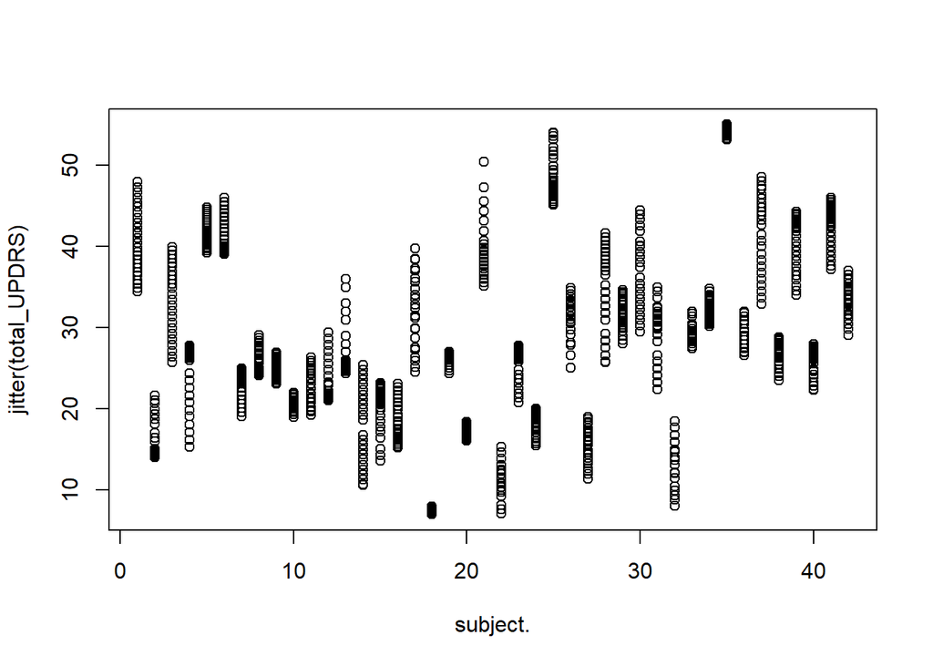

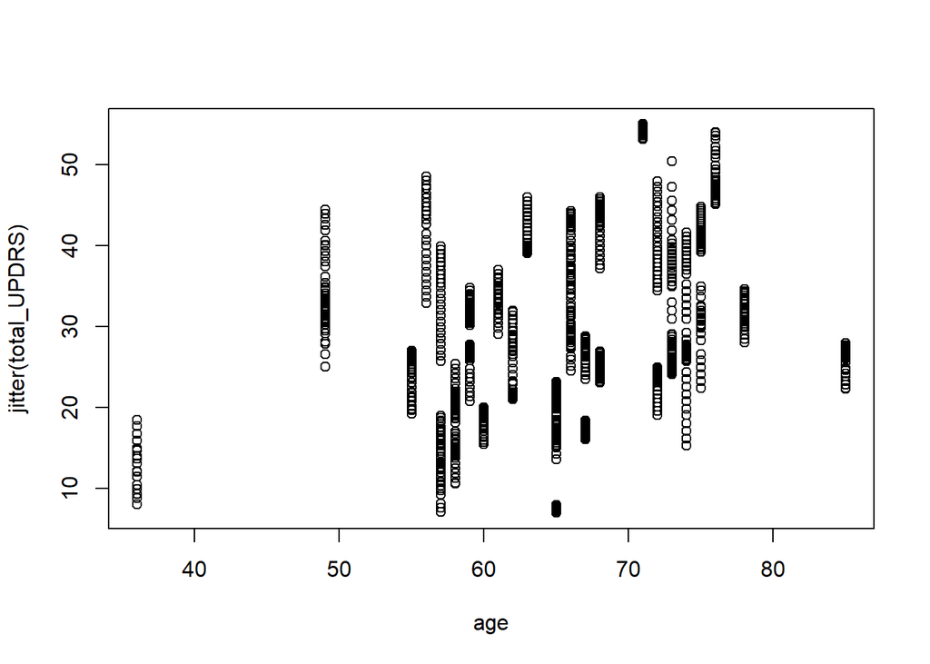

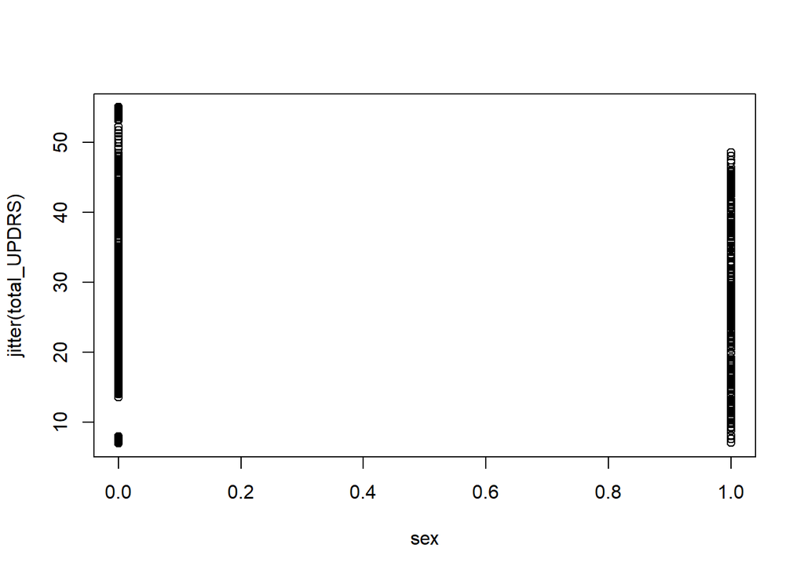

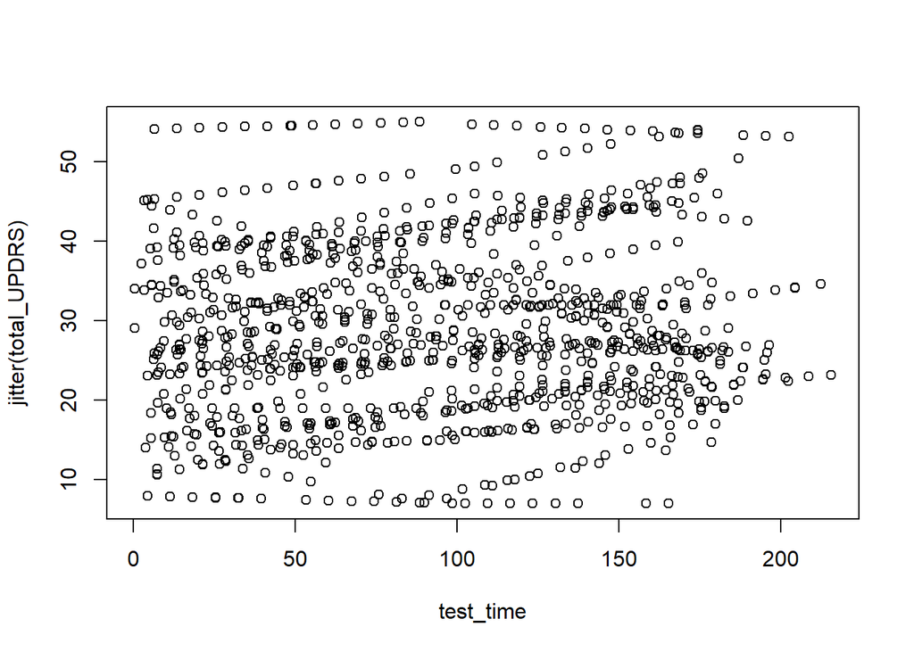

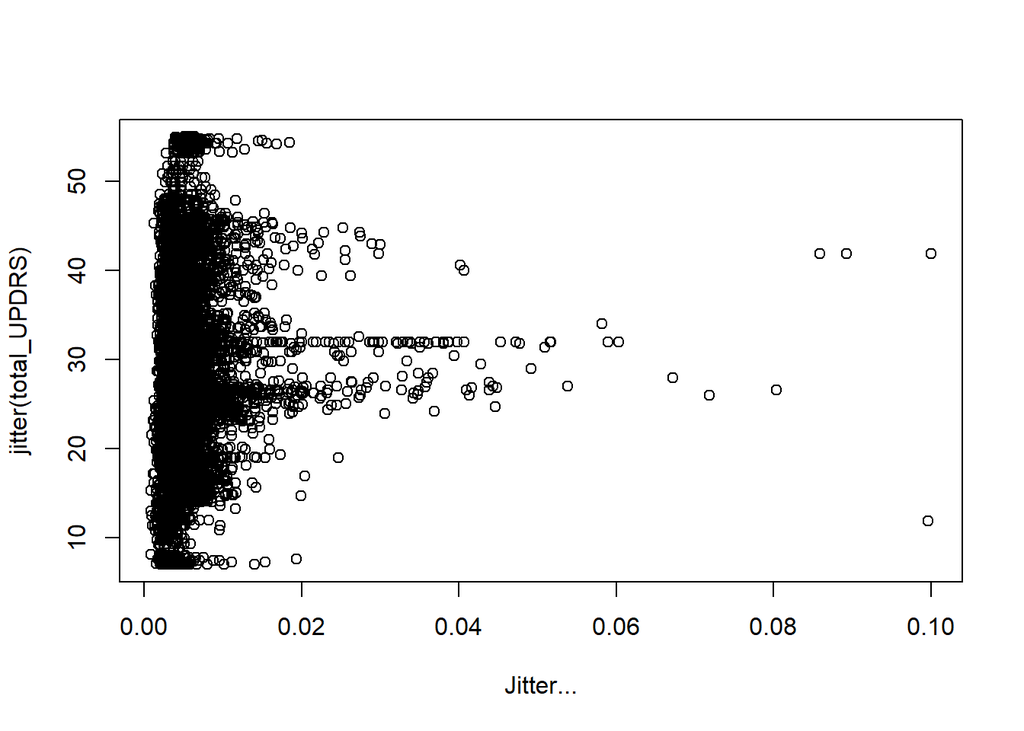

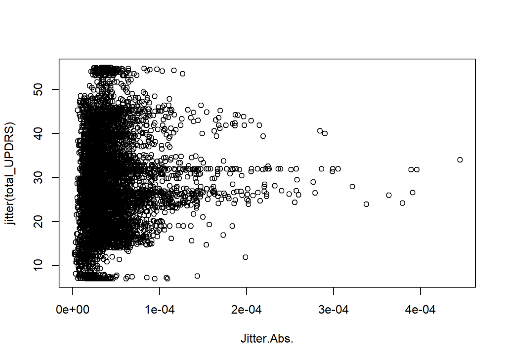

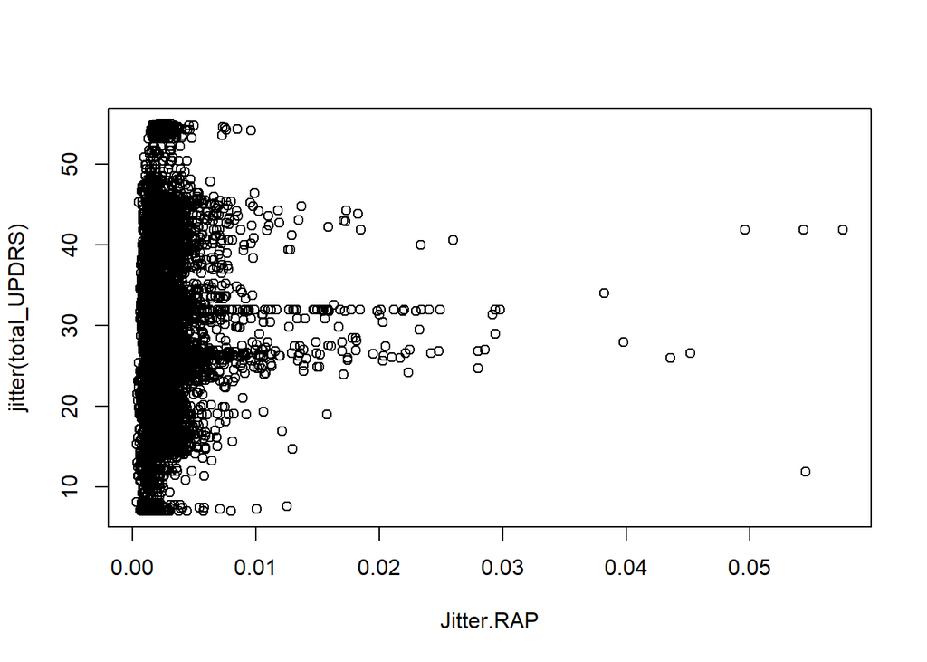

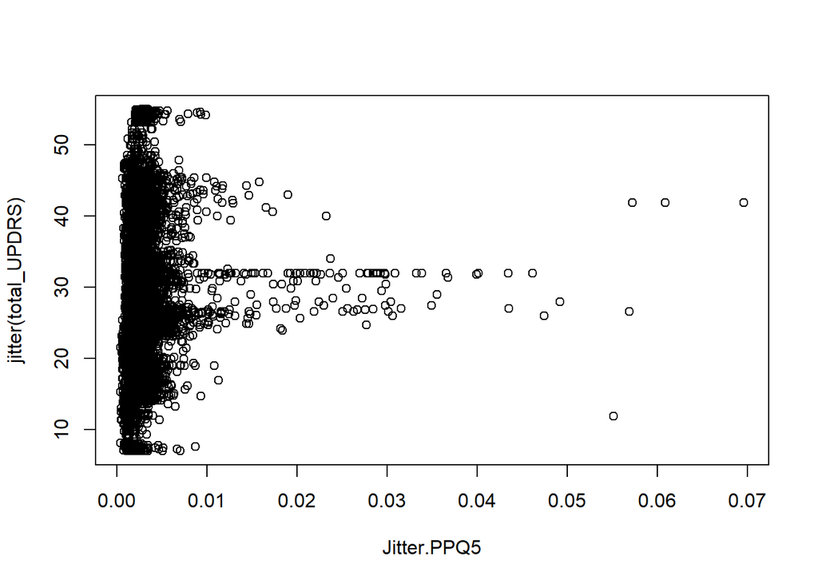

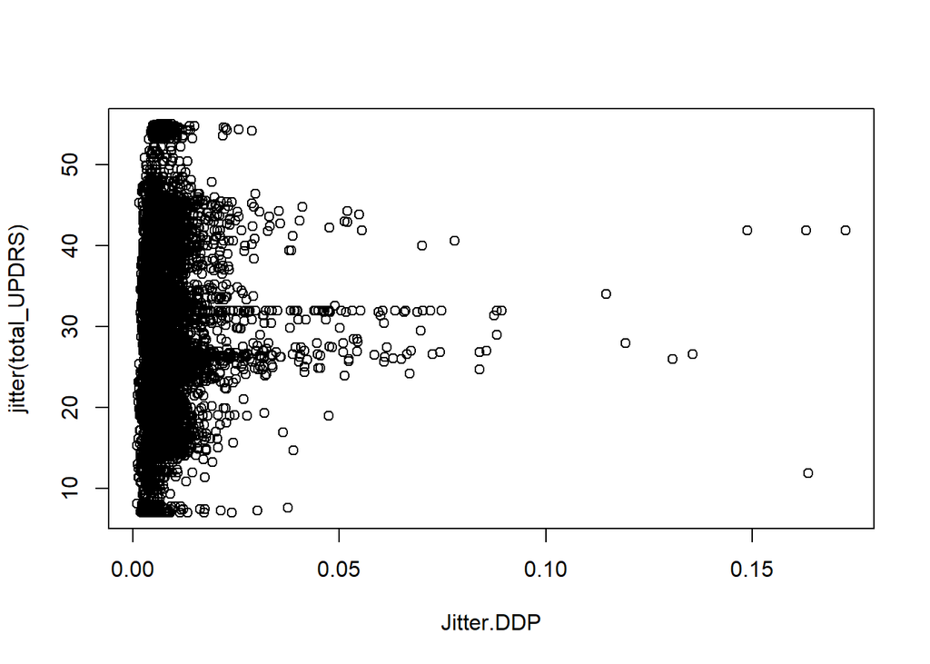

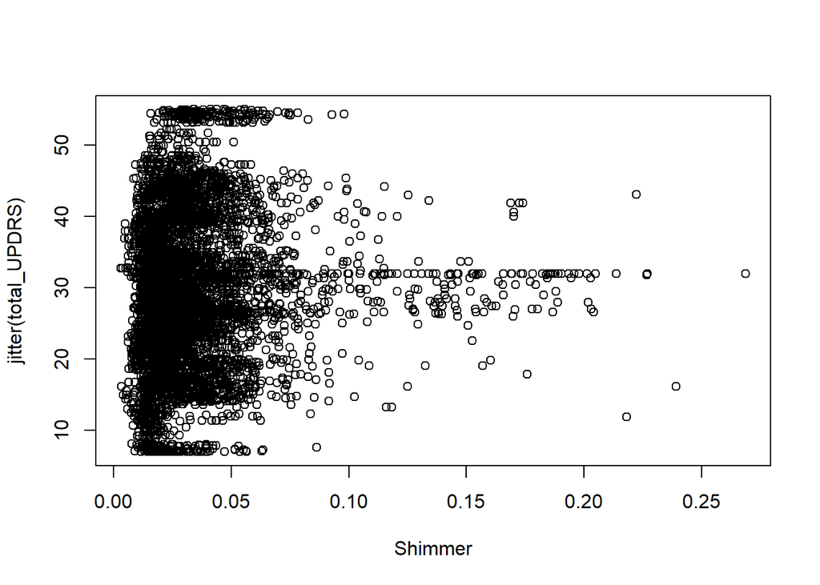

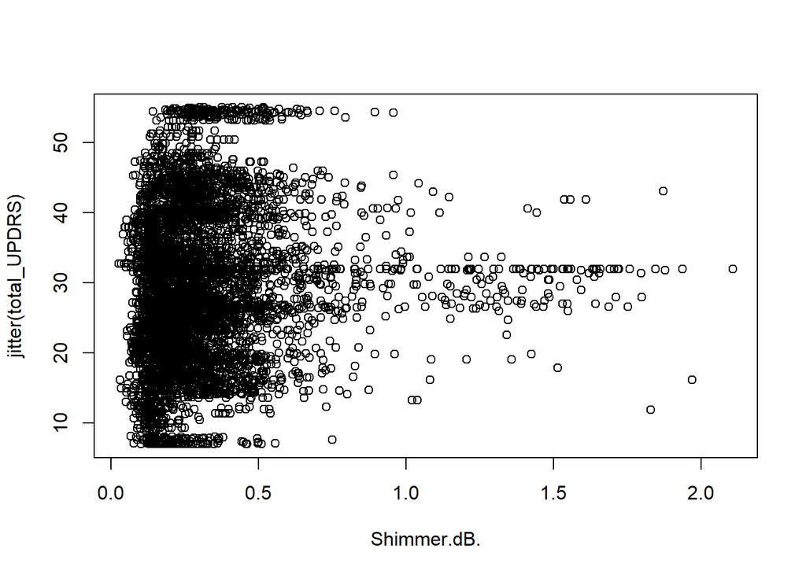

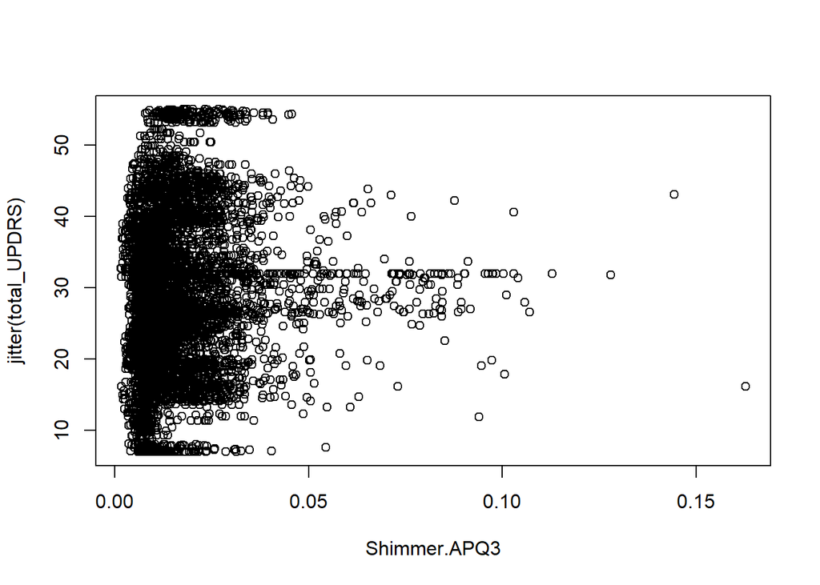

[8 more figures not shown]

```r
#Scattered plot to look into data distribution
plot(jitter(total_UPDRS)~., parkinsons)
```

We can see there are outliers in the data form the plot between Jitter vs UPDRS, for plot Shimmer vs UPDRS, for plot NHR vs UPDRS, for RPDE vs UPDRS, DFA vs UPDRS and PPE vs UPDRS there are outlier observations.

We will now plot to check outlier observations using bivariate plots.

```r
library(MVA)
```

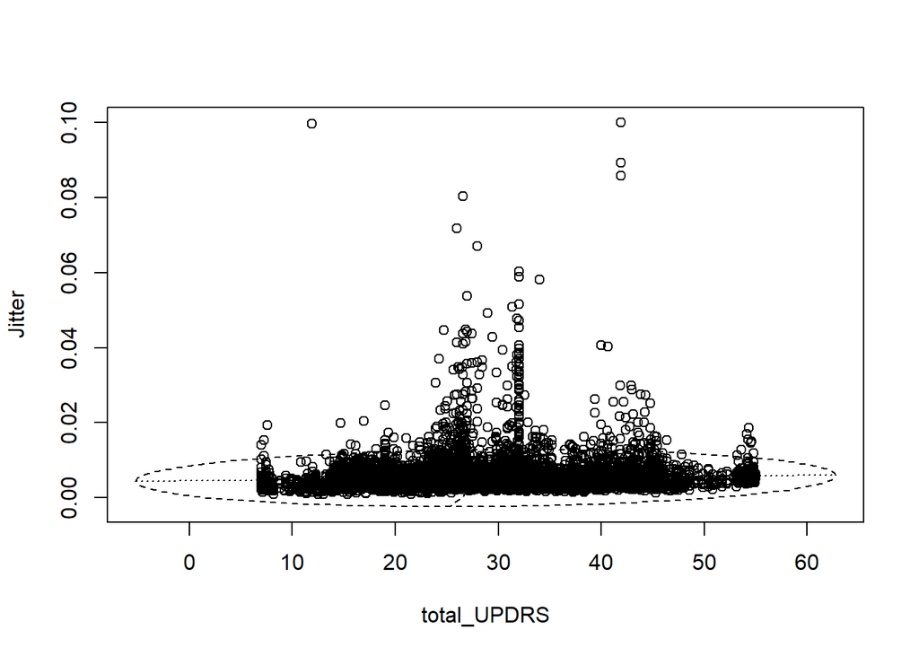

```r
#boxplots
bvbox(parkinsons[,5:6], xlab = "total_UPDRS", ylab = "Jitter")
```

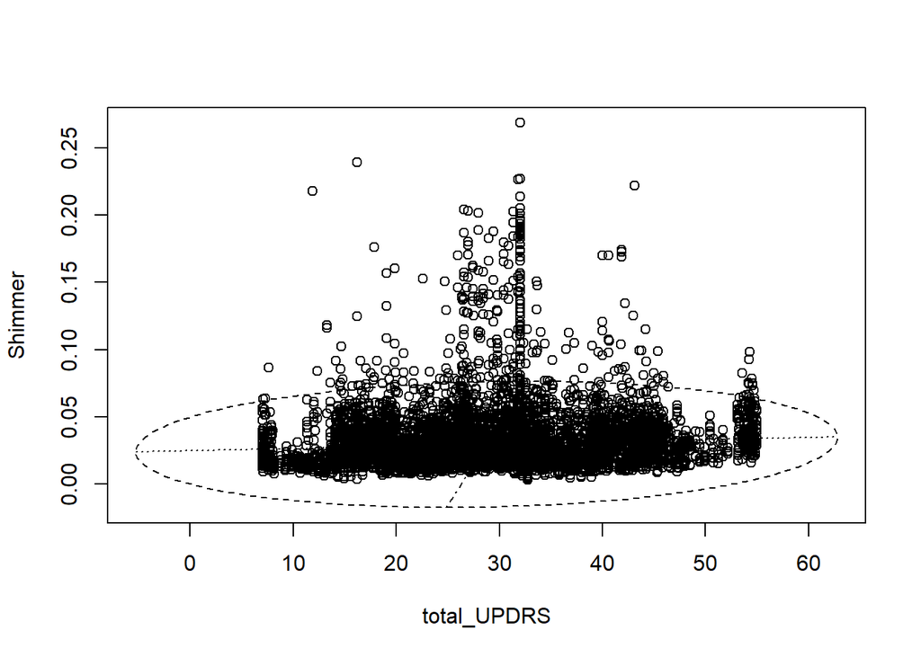

```r
bvbox(parkinsons[,c(5,11)], xlab = "total_UPDRS", ylab = "Shimmer")
```

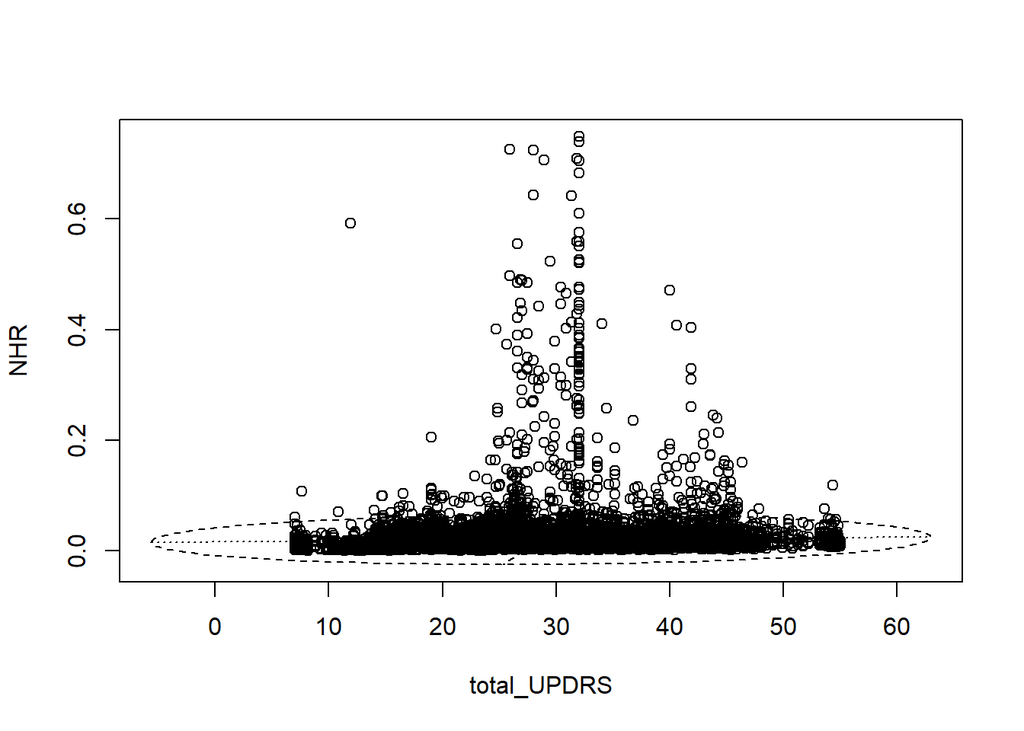

```r
bvbox(parkinsons[,c(5,17)], xlab = "total_UPDRS", ylab = "NHR")
```

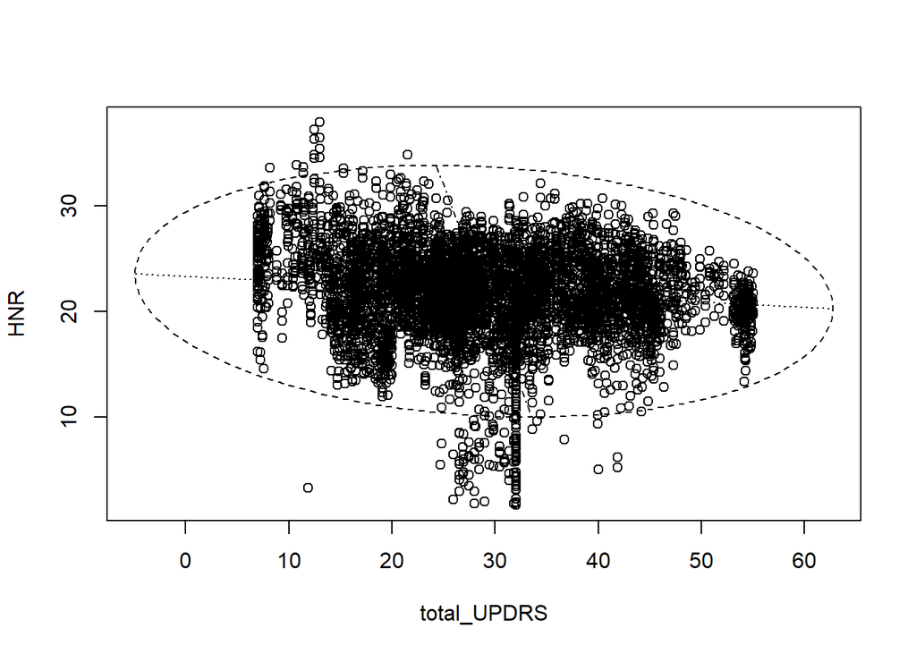

```r
bvbox(parkinsons[,c(5,18)], xlab = "total_UPDRS", ylab = "HNR")
```

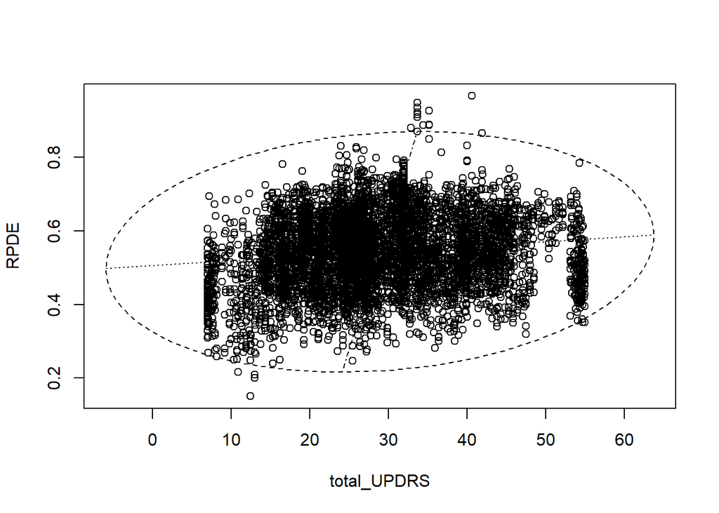

```r
bvbox(parkinsons[,c(5,19)], xlab = "total_UPDRS", ylab = "RPDE")
```

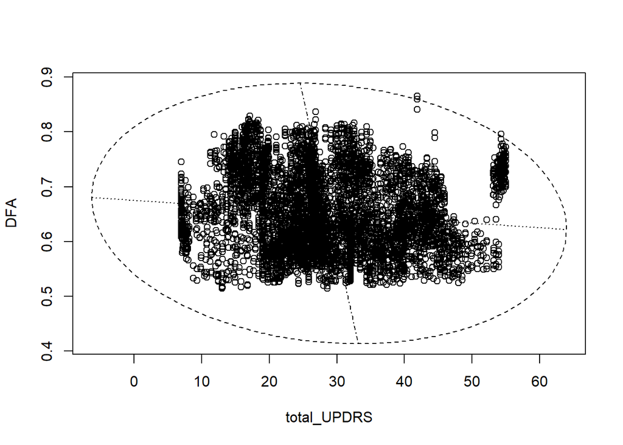

```r
bvbox(parkinsons[,c(5,20)], xlab = "total_UPDRS", ylab = "DFA")
```

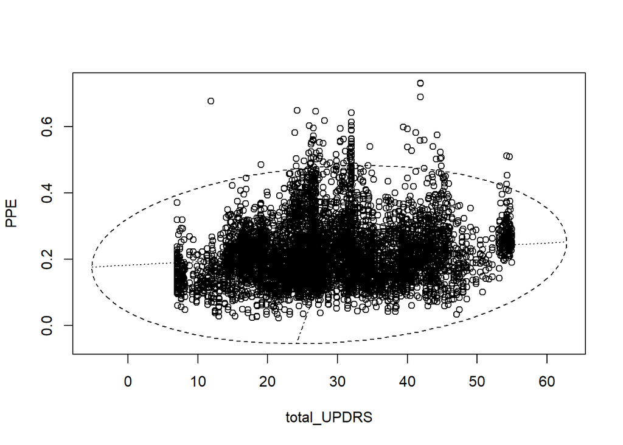

```r
bvbox(parkinsons[,c(5,21)], xlab = "total_UPDRS", ylab = "PPE")
```

We know from a fact that HNR and NHR are inversely proportional to voice quality. If high HNR, the patient has superior voice quality, if HNR is low the patient has low voice quality and vice versa. Since, NHR are having high number of outliers as seen from the scattered plot and bivariate plot and because NHR and HNR are inversely proportional, we are removing NHR to reduce the dimentionality.

```r
#Removing NHR variable

parkinsons <- select(parkinsons, -c(17))
```

The plots show a lot of outlier observations in the data. We are using Convex Hull method to remove some outliers.

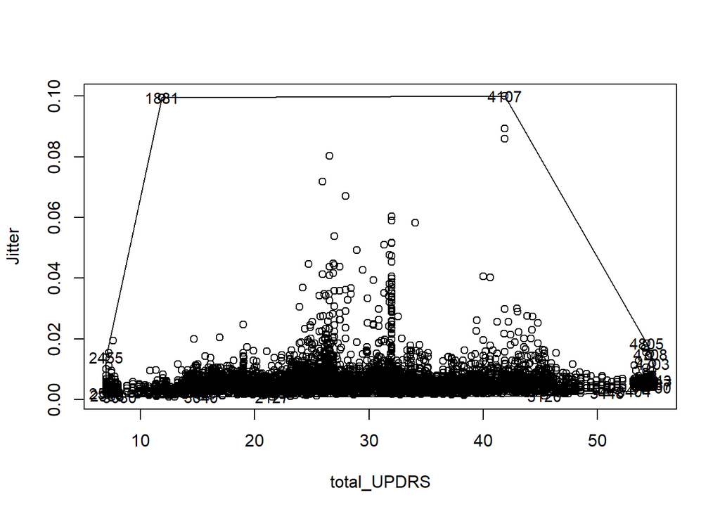

```r
#Plotting Convex Hull curve
hull1 <- chull(parkinsons[,5:6])
parkhull <- match(lab <- rownames(parkinsons[hull1,])
, rownames(parkinsons))
plot(parkinsons[,5:6], xlab = "total_UPDRS", ylab = "Jitter")
polygon(parkinsons$Jitter...[hull1]~parkinsons$total_UPDRS[hull1])
text(parkinsons[parkhull,5:6], labels = lab
, pch=".", cex = 0.9)
```

```r
#Removing outlier observations according to Convex hull
outlier <- parkinsons[-hull1,]

dim(outlier)
```

```
## [1] 5846   20
```

```r
dim(parkinsons)
```

```
## [1] 5863   20
```

```r
hull2 <- chull(outlier[,c(5,11)])

parkinsons <- outlier[-hull2,]

hull3 <- chull(outlier[,c(5,16)])
parkinsons <- outlier[-hull3,]

hull4 <- chull(outlier[,c(5,18)])

parkinsons <- outlier[-hull3,]

hull4 <- chull(parkinsons[,c(6,19)])

outlier <- parkinsons[-hull4,]

hull5 <- chull(outlier[,c(6,20)])

parkinsons <- outlier[-hull5,]

dim(parkinsons)
```

```
## [1] 5794   20
```

We have removed outliers using Convex Hull method. We then normalize data and apply Principle Component Analysis to further reduce dimensionality.

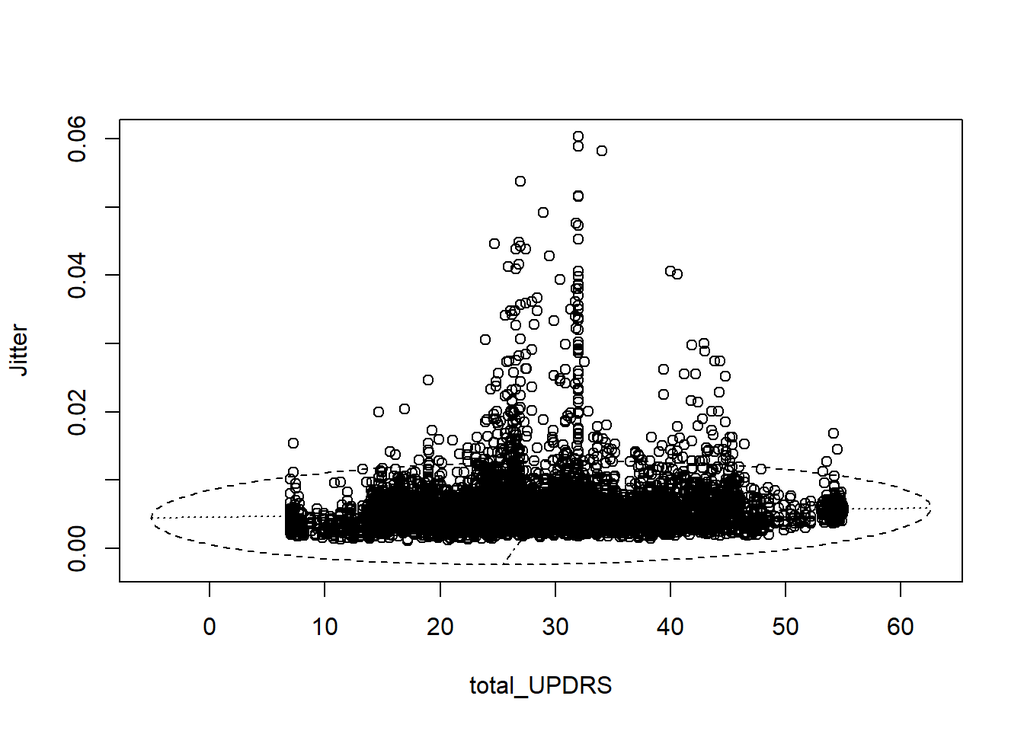

```r
#Plot for a variable after removing some outliers.

bvbox(parkinsons[,5:6], xlab = "total_UPDRS", ylab = "Jitter")
```

From the above graph we could see that only some of the outliers have been removed using Convex Hull method. So we have decided to use Ensemble Regression methods, such as Random Forests which are very much robust to outliers.

##### Data Normalization

Before applying PCA, we are normalizing data so as to have best variance explained by PCA.

We have decided to use preProcess() to normalize data to a range of [0,1].

```r
stargazer::stargazer(parkinsons, type = 'text')
```

```
##
## ======================================================================
## Statistic       N    Mean   St. Dev.   Min   Pctl(25) Pctl(75)   Max
## ----------------------------------------------------------------------
## subject.      5,794 21.432   12.375     1       10       32      42
## age           5,794 64.824   8.842     36       58       72      85
## sex           5,794  0.318   0.466      0       0        1        1
## test_time     5,794 93.246   53.282   0.396   47.372  138.470  215.490
## total_UPDRS   5,794 28.994   10.606   7.000   21.489   36.375  54.992
## Jitter...     5,794  0.006   0.005    0.001   0.004    0.007    0.060
## Jitter.Abs.   5,794 0.00004 0.00003  0.00000 0.00002   0.0001  0.0004
## Jitter.RAP    5,794  0.003   0.003   0.0004   0.002    0.003    0.038
## Jitter.PPQ5   5,794  0.003   0.003    0.001   0.002    0.003    0.046
## Jitter.DDP    5,794  0.009   0.008    0.001   0.005    0.010    0.115
## Shimmer       5,794  0.034   0.025    0.004   0.019    0.040    0.269
## Shimmer.dB.   5,794  0.308   0.222    0.034   0.176    0.363    2.107
## Shimmer.APQ3  5,794  0.017   0.013    0.002   0.009    0.021    0.128
## Shimmer.APQ5  5,794  0.020   0.016    0.002   0.011    0.024    0.167
## Shimmer.APQ11 5,794  0.027   0.019    0.003   0.016    0.033    0.247
## Shimmer.DDA   5,794  0.051   0.038    0.005   0.028    0.062    0.384
## HNR           5,794 21.679   4.186    1.659   19.422   24.419  36.448
## RPDE          5,794  0.542   0.100    0.209   0.471    0.614    0.966
## DFA           5,794  0.653   0.071    0.517   0.596    0.711    0.823
## PPE           5,794  0.219   0.089    0.028   0.157    0.264    0.647
## ----------------------------------------------------------------------
```

```r
#parkinsons$subject.<- (parkinsons$subject. - mean(parkinsons$subject.)) / sd(parkinsons$subject.)
#parkinsons$age <- (parkinsons$age - mean(parkinsons$age)) / sd(parkinsons$age)
#parkinsons$test_time <- (parkinsons$test_time - mean(parkinsons$test_time)) / sd(parkinsons$test_time)
#parkinsons$HNR <- (parkinsons$HNR - mean(parkinsons$HNR)) / sd(parkinsons$HNR)

preprocessParams <- preProcess(parkinsons, method = c("range"))

parkinsons_scaled <- predict(preprocessParams, parkinsons)
```

```r
stargazer::stargazer(parkinsons_scaled, type = 'text')
```

```
##
## ================================================================
## Statistic       N   Mean  St. Dev.  Min  Pctl(25) Pctl(75)  Max
## ----------------------------------------------------------------
## subject.      5,794 0.498  0.302     0     0.2      0.8      1
## age           5,794 0.588  0.180   0.000  0.449    0.735   1.000
## sex           5,794 0.318  0.466     0      0        1       1
## test_time     5,794 0.432  0.248   0.000  0.218    0.642   1.000
## total_UPDRS   5,794 0.458  0.221   0.000  0.302    0.612   1.000
## Jitter...     5,794 0.083  0.082   0.000  0.041    0.096   1.000
## Jitter.Abs.   5,794 0.090  0.078   0.000  0.042    0.112   1.000
## Jitter.RAP    5,794 0.066  0.070   0.000  0.030    0.075   1.000
## Jitter.PPQ5   5,794 0.058  0.070   0.000  0.028    0.064   1.000
## Jitter.DDP    5,794 0.066  0.070   0.000  0.030    0.075   1.000
## Shimmer       5,794 0.113  0.094   0.000  0.058    0.135   1.000
## Shimmer.dB.   5,794 0.132  0.107   0.000  0.068    0.159   1.000
## Shimmer.APQ3  5,794 0.121  0.100   0.000  0.060    0.149   1.000
## Shimmer.APQ5  5,794 0.108  0.097   0.000  0.052    0.130   1.000
## Shimmer.APQ11 5,794 0.100  0.079   0.000  0.052    0.122   1.000
## Shimmer.DDA   5,794 0.121  0.100   0.000  0.060    0.149   1.000
## HNR           5,794 0.575  0.120   0.000  0.511    0.654   1.000
## RPDE          5,794 0.439  0.132   0.000  0.346    0.535   1.000
## DFA           5,794 0.446  0.230   0.000  0.260    0.635   1.000
## PPE           5,794 0.309  0.145   0.000  0.208    0.381   1.000
## ----------------------------------------------------------------
```

## Principal Componenet Analysis

```r
parkinsons.pca1 <- prcomp(select(parkinsons_scaled, c(1:4,6:20)), center = TRUE, scale. = TRUE)

summary(parkinsons.pca1)
```

```
## Importance of components:
##                           PC1     PC2     PC3     PC4     PC5     PC6     PC7
## Standard deviation     3.2627 1.32617 1.17878 1.06218 1.00705 0.99406 0.84915
## Proportion of Variance 0.5603 0.09257 0.07313 0.05938 0.05338 0.05201 0.03795
## Cumulative Proportion  0.5603 0.65285 0.72598 0.78536 0.83874 0.89075 0.92870
##                            PC8     PC9    PC10   PC11    PC12   PC13    PC14
## Standard deviation     0.73954 0.53161 0.41384 0.3801 0.31828 0.2386 0.14973
## Proportion of Variance 0.02879 0.01487 0.00901 0.0076 0.00533 0.0030 0.00118
## Cumulative Proportion  0.95748 0.97236 0.98137 0.9890 0.99431 0.9973 0.99848
##                           PC15    PC16    PC17      PC18      PC19
## Standard deviation     0.12062 0.09873 0.06718 0.0007279 0.0001506
## Proportion of Variance 0.00077 0.00051 0.00024 0.0000000 0.0000000
## Cumulative Proportion  0.99925 0.99976 1.00000 1.0000000 1.0000000
```

From the PCA done above for all variables we can see that components PC1, PC2, PC3, PC4, PC5, PC6, PC7 and PC8 combined can explain 95% variance. So 8 predictors are very much sufficient to predict total_UPDRS score. This indicates that we would we obtaining a good solution.

```r
#PCA Loadings
parkinsons.pca1$rotation
```

```
##                        PC1         PC2          PC3           PC4          PC5
## subject.       0.054334195 -0.04337385  0.415072473  0.6566984094 -0.145231440
## age            0.030942784 -0.14737357 -0.232458329 -0.1404349848 -0.576123949
## sex            0.006969547 -0.23022441  0.678075021  0.0839535705 -0.070194814
## test_time     -0.006732844  0.04387760  0.008203925  0.0052009457 -0.782287502
## Jitter...      0.275587553  0.24082259  0.171565658 -0.1678738326 -0.026131593
## Jitter.Abs.    0.257554751  0.34466045 -0.037282444 -0.0806366563 -0.008115541
## Jitter.RAP     0.267720444  0.24635511  0.209152708 -0.2041395759 -0.012827275
## Jitter.PPQ5    0.272486578  0.15251953  0.197424552 -0.1858676760 -0.010118346
## Jitter.DDP     0.267721945  0.24635859  0.209146318 -0.2041292236 -0.012838703
## Shimmer        0.285792067 -0.24962856 -0.049702739  0.0003510202  0.039403980
## Shimmer.dB.    0.286030695 -0.23948171 -0.050900085 -0.0064512844  0.027715085
## Shimmer.APQ3   0.278730583 -0.25961592 -0.065944430 -0.0203283844  0.050148234
## Shimmer.APQ5   0.281056792 -0.26228480 -0.046896768 -0.0002239184  0.051801830
## Shimmer.APQ11  0.268306756 -0.25353521 -0.112517848  0.1030376667  0.015798117
## Shimmer.DDA    0.278730204 -0.25961684 -0.065943738 -0.0203302313  0.050146061
## HNR           -0.267367724  0.01317757  0.107052568 -0.2115116574  0.011300346
## RPDE           0.175048831  0.11461468 -0.270958278  0.3145328059 -0.042488997
## DFA            0.076887534  0.36521153 -0.180533548  0.4638545003  0.089428076
## PPE            0.241293644  0.25653260 -0.102213901  0.1380702342 -0.093240693
##                       PC6          PC7         PC8         PC9         PC10
## subject.      -0.17938864 -0.139745539 -0.55911268 -0.04158340 -0.022221049
## age           -0.65276460  0.355256291 -0.04172119 -0.12592133 -0.023266277
## sex           -0.09377465  0.180207632  0.63201223  0.02379424  0.063775275
## test_time      0.60519217 -0.129198994  0.04909357 -0.01357240 -0.006889184
## Jitter...     -0.04620713 -0.020044347 -0.05827142 -0.05169208  0.090602696
## Jitter.Abs.   -0.03638767 -0.050036749 -0.04930767 -0.03896880 -0.008145176
## Jitter.RAP    -0.03815129  0.006854841 -0.05291898 -0.14878279 -0.103910203
## Jitter.PPQ5   -0.01316414 -0.010940270 -0.07784701 -0.05220249  0.170621030
## Jitter.DDP    -0.03814073  0.006868589 -0.05295489 -0.14875778 -0.103917196
## Shimmer        0.08469790  0.034754156 -0.03969808 -0.03842100  0.059599439
## Shimmer.dB.    0.07166962  0.026869492 -0.03441052  0.01607971  0.105652665
## Shimmer.APQ3   0.11105476  0.060885858 -0.03791826 -0.09219667 -0.186459290
## Shimmer.APQ5   0.09777415  0.042782407 -0.03742177 -0.03223361  0.126539249
## Shimmer.APQ11  0.04583335  0.061181875 -0.03203966  0.10549628  0.436271241
## Shimmer.DDA    0.11105845  0.060892453 -0.03792134 -0.09219457 -0.186468449
## HNR            0.06184275  0.092735949 -0.20748123 -0.22914186  0.744892184
## RPDE          -0.21982347 -0.568788535  0.42797824 -0.39234723  0.210303256
## DFA            0.21596311  0.674208674  0.14302481 -0.26535882  0.043903983
## PPE           -0.11269121  0.019535322  0.10760301  0.78912763  0.210359277
```

[output cut: 25 more lines]

```
## Jitter...     -0.845472580  0.1404799417 -3.737738e-05 -2.070102e-05
## Jitter.Abs.    0.096740529 -0.0422238613  2.363585e-05  1.836851e-06
## Jitter.RAP     0.208080601 -0.0139345029 -7.070670e-01  1.902768e-03
## Jitter.PPQ5    0.338261553 -0.1003555746 -7.043922e-05  6.804150e-06
## Jitter.DDP     0.208120894 -0.0137962840  7.071414e-01 -1.891697e-03
## Shimmer        0.169727747  0.8521069795 -1.033498e-04  4.615455e-05
## Shimmer.dB.    0.017203368 -0.4444622146 -1.857287e-05 -1.395084e-05
## Shimmer.APQ3  -0.036095894 -0.1188185198 -1.902075e-03 -7.071116e-01
## Shimmer.APQ5  -0.188490899 -0.1102975677  1.870662e-04 -1.874324e-05
## Shimmer.APQ11  0.066643327 -0.0589530916 -3.994440e-05  1.420158e-06
## Shimmer.DDA   -0.036144495 -0.1188822939  1.892400e-03  7.070969e-01
## HNR            0.026630824 -0.0103298725  2.699626e-05  5.245505e-06
## RPDE           0.014279454 -0.0100160518  2.475240e-05  6.862533e-06
## DFA           -0.005739610 -0.0006723951 -9.411732e-06 -1.744180e-06
## PPE            0.046181680  0.0130940778  8.531029e-06  3.428419e-06
```

#### Scree Plot

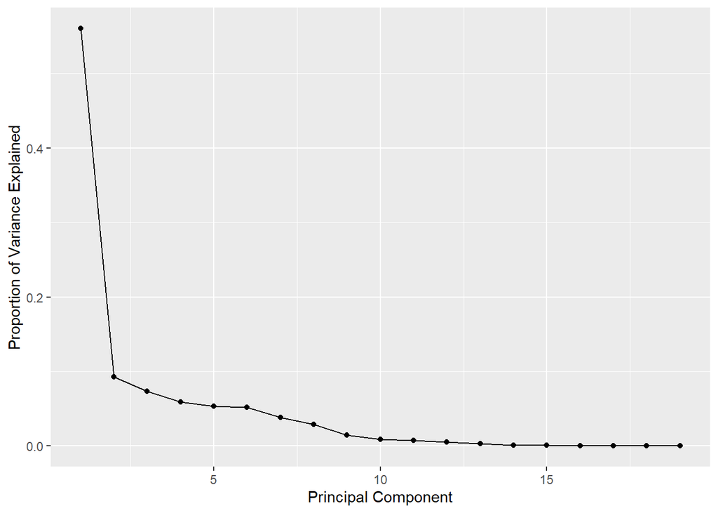

```r
pc_var <- parkinsons.pca1$sdev^2

pc_var_prop <- pc_var/sum(pc_var)

p1 <- qplot(y = pc_var_prop)+
  geom_line()+
  ylab("Proportion of Variance Explained")+
  xlab("Principal Component")

p1
```

# Predictive Modeling

The first step for predictive modeling is to split the data into training and testing data.

Here we are splitting the data into 80/20 ratio.

```r
library(parallel)
library(doParallel)
cl <- makePSOCKcluster(detectCores() - 1)
registerDoParallel(cl)

set.seed(123)
#trainIndex <- createDataPartition(parkinsons$total_UPDRS, p = .8, list = FALSE)

#train_data <- parkinsons[trainIndex,]
#test_data <- parkinsons[-trainIndex,]

#train_data
#test_data

index <- sample(1:nrow(parkinsons), as.integer(0.8*nrow(parkinsons)))
index[1:20]
```

```
##  [1] 2463 2511 2227  526 4291 2986 1842 1142 3371 5349 5364 5134 3446 4761 1627
## [16] 2757 5107 5211  953 4444
```

```r
train_data <- parkinsons[index,]
test_data <- parkinsons[-index,]
```

There are 4635 training observations and 1159 testing observations. Let us now do the predictive modeling using Random Forest.

## Random Forest

```r
library(randomForest)
set.seed(500)


rf<- randomForest(total_UPDRS~., data = train_data,
                  mtry = 6, importance = TRUE)

rf
```

```
##
## Call:
##  randomForest(formula = total_UPDRS ~ ., data = train_data, mtry = 6,      importance = TRUE)
##                Type of random forest: regression
##                      Number of trees: 500
## No. of variables tried at each split: 6
##
##           Mean of squared residuals: 3.251509
##                     % Var explained: 97.12
```

```r
#Testing the performance of the random forest on testing data.
rf_yhat <- predict(rf, newdata = test_data)

postResample(rf_yhat, test_data$total_UPDRS)
```

```
##     RMSE Rsquared      MAE
## 1.864691 0.973318 1.311123
```

With R-squared value being 97.3% Random forest does perform well for this data.

Now let us check feature importance of each predictor and plot the features:

```r
importance(rf)
```

```
##                 %IncMSE IncNodePurity
## subject.      115.10003    189978.563
## age            82.67217    158106.223
## sex            35.99162     16569.558
## test_time     110.24504     19465.278
## Jitter...      13.42193      4313.210
## Jitter.Abs.    25.38407     13186.842
## Jitter.RAP     17.01329      3793.304
## Jitter.PPQ5    18.14988      4311.759
## Jitter.DDP     15.63187      4035.510
## Shimmer        12.72395      4192.255
## Shimmer.dB.    13.26995      3552.444
## Shimmer.APQ3   17.26220      4947.709
## Shimmer.APQ5   19.27815      5233.744
## Shimmer.APQ11  13.11641      5878.593
## Shimmer.DDA    13.58533      5062.918
## HNR            22.12342     14305.532
## RPDE           27.77647     14759.037
## DFA            44.34762     38244.568
## PPE            18.48144      9321.598
```

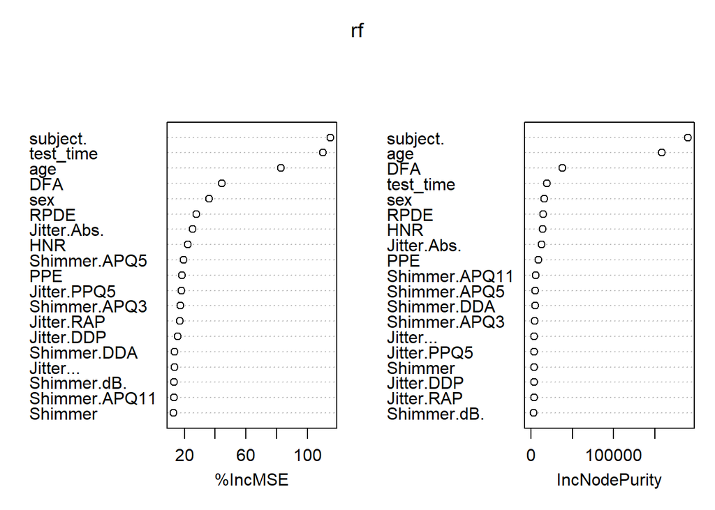

```r
varImpPlot(rf)
```

Observations: The most important features are subject, age and test_time.

Let us evaluate the performance of the model.

We will predict the model based on testing data and compare the actual values with the predicted values and check the correlation between them.

```r
pred <- predict(rf, test_data, type = 'response')

summary(pred)
```

```
##    Min. 1st Qu.  Median    Mean 3rd Qu.    Max.
##   8.271  21.926  27.871  28.621  34.292  54.586
```

```r
summary(parkinsons$total_UPDRS)
```

```
##    Min. 1st Qu.  Median    Mean 3rd Qu.    Max.
##    7.00   21.49   27.52   28.99   36.38   54.99
```

```r
cor(pred, test_data$total_UPDRS)
```

```
## [1] 0.9865688
```

The correlation between the actual and predicted values is 98% which shows both the values are strongly related. Comparing the true and predicted values with MAE:

```r
MAE <- function(actual,predicted){
  mean(abs(actual - predicted))
}

MAE(pred, test_data$total_UPDRS)
```

```
## [1] 1.311123
```

With the difference being 1.30, we can say the model performs fairly well.

```r
#library(lubridate)
#tuneGrid <- data.frame(mtry =1:19)

#3control <- trainControl(method = 'repeatedcv',
#                        number = 10,
#                        repeats = 3)
#set.seed(123)

# print out system time before training
#start_t <- Sys.time()
#cat("",cat("Training started at:",format(start_t, "%a %b %d %X %Y")))

#rf_tuned <- train(total_UPDRS ~ ., data = train_data,
#                  method = 'rf',
#                  trControl = control,
#                  tuneGrid = tuneGrid)

# print out system time after training
#finish_t <- Sys.time()
#cat("",cat("Training finished at:",format(finish_t, "%a %b %d %X %Y")))

#cat("The training process finished in",difftime(finish_t,start_t,units="mins"), "minutes")

#print(rf_tuned)
```

```r
# plot(rf_tuned)
```

# Bagging

```r
set.seed(123)
bag_park <- randomForest(total_UPDRS~., data = train_data,
                  mtry = 19, importance = TRUE)

bag_park
```

```
##
## Call:
##  randomForest(formula = total_UPDRS ~ ., data = train_data, mtry = 19,      importance = TRUE)
##                Type of random forest: regression
##                      Number of trees: 500
## No. of variables tried at each split: 19
##
##           Mean of squared residuals: 0.1575012
##                     % Var explained: 99.86
```

```r
#Testing the performance with best parameter on testing data.
rf_yhat <- predict(bag_park, newdata = test_data)

postResample(rf_yhat, test_data$total_UPDRS)
```

```
##      RMSE  Rsquared       MAE
## 0.5189474 0.9976167 0.1841225
```

We can see that there is a significant decrease in RMSE value and an increase of 2% in Rsquared when applied bagging model.

# Gradient Boosting Machine

```r
#Importing the gbm library
set.seed(123)
library(gbm)
model_gbm = gbm(train_data$total_UPDRS ~.,
                data = train_data,
                distribution = "gaussian",
                cv.folds = 10,
                shrinkage = .01,
                n.minobsinnode = 10,
                n.trees = 500)

print(model_gbm)
```

```
## gbm(formula = train_data$total_UPDRS ~ ., distribution = "gaussian",
##     data = train_data, n.trees = 500, n.minobsinnode = 10, shrinkage = 0.01,
##     cv.folds = 10)
## A gradient boosted model with gaussian loss function.
## 500 iterations were performed.
## The best cross-validation iteration was 500.
## There were 19 predictors of which 3 had non-zero influence.
```

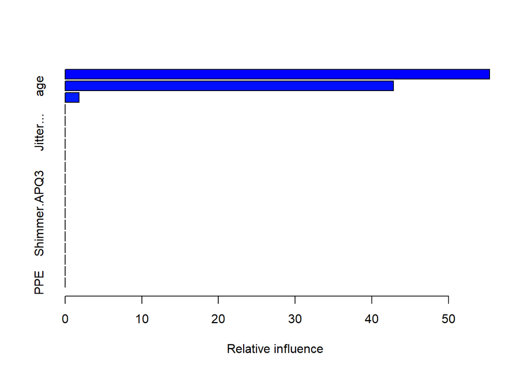

```
##                         var   rel.inf
## subject.           subject. 55.367171
## age                     age 42.819781
## DFA                     DFA  1.813047
## sex                     sex  0.000000
## test_time         test_time  0.000000
## Jitter...         Jitter...  0.000000
## Jitter.Abs.     Jitter.Abs.  0.000000
## Jitter.RAP       Jitter.RAP  0.000000
## Jitter.PPQ5     Jitter.PPQ5  0.000000
## Jitter.DDP       Jitter.DDP  0.000000
## Shimmer             Shimmer  0.000000
## Shimmer.dB.     Shimmer.dB.  0.000000
## Shimmer.APQ3   Shimmer.APQ3  0.000000
## Shimmer.APQ5   Shimmer.APQ5  0.000000
## Shimmer.APQ11 Shimmer.APQ11  0.000000
## Shimmer.DDA     Shimmer.DDA  0.000000
## HNR                     HNR  0.000000
## RPDE                   RPDE  0.000000
## PPE                     PPE  0.000000
```

```r
summary(model_gbm)
```

Predicting the performance using test data

```r
test1 <-test_data[,-5]
test2 <- test_data[,5]
pred <- predict.gbm(model_gbm, test1)
```

```
## Using 500 trees...
```

```r
gbm_result <- postResample(pred, test_data$total_UPDRS)

gbm_result
```

```
##      RMSE  Rsquared       MAE
## 8.0067602 0.4781056 6.4771474
```

We can see from the above statistics that RMSE value is 8.01 and Rsquared value is 0.479 which shows it performs poor compared to Random Forest.

# Support Vector Machine

```r
library(e1071)

set.seed(123)

preprocessParams <- preProcess(train_data, method = c("scale", "center"))

print(preprocessParams)
```

```
## Created from 4635 samples and 20 variables
##
## Pre-processing:
##   - centered (20)
##   - ignored (0)
##   - scaled (20)
```

```r
train_scaled <-predict(preprocessParams, train_data)
test_scaled <- predict(preprocessParams, test_data)

svm_cv <- function(data, response, nfold, kernel){
  set.seed(100)
  f <- as.formula(paste(response, '~.'))
  if (kernel == 'radial'){
    svm_tune <- tune(svm, f, data = parkinsons,
                     kernel = 'radial',
                     tuneControl = tune.control(
                       cross = nfolds, sampling = "cross"),
                     ranges = list(cost = 10 ^(-2:2), gamma = 10 ^ (-2:2)))

  } else if(kernel =="linear"){
    svm_tune <- tune(svm, f, data = parkinsons,
                     kernel = 'linear',
                     tuneControl = tune.control(
                       cross = nfolds, sampling = "cross"),
                     ranges = list(cost = 10 ^(-2:2)))
  } else{
    svm_tune <- tune(svm, f, data = parkinsons,
                     kernel = 'polynomial',
                     tuneControl = tune.control(
                       cross = nfolds, sampling = "cross"),
                     ranges = list(cost = 10 ^(-2:2)))
  }

  print(summary(svm_tune))
  print(svm_tune$best.parameters)
  print(svm_tune$best.performance)
  return(svm_tune)
}

svm_cv_caret <- function(data, response, nfolds, repeats, kernel){
  set.seed(100)
  f <- as.formula(paste(response, '~ .'))
  tuneGrid <- data.frame(C = 10 ^ (-2: 2))
  if(kernel == 'svmRadial'){
    tuneGrid <- data.frame(C = 10 ^ (-2: 2),
                           sigma = 10 ^ (-2: 2))
  } else if(kernel == 'svmPoly'){
    tuneGrid <- data.frame(C = 10 ^ (-2: 2),
                           degree = (1: 5),
                           scale = 10 ^ (-4: 0))
  }
  print(tuneGrid)
  control <- trainControl(method = 'repeatedcv',
                          number = nfolds,
                          repeats = repeats)
  svm_tuned <- train(f, data = parkinsons,
                     method = kernel,
                     trControl = control,
                     tuneGrid = tuneGrid)
  print(svm_tuned)
  print(svm_tuned$bestTune)
  plot(svm_tuned)
  return(svm_tuned)
}
```

#### Linear Kernel

```r
#tune_svm_linear <- svm_cv_caret(train_scaled, 'total_UPDRS', 10, 1, 'svmLinear')
```

#### Radial Model

```r
#tune_svm_radial <- svm_cv_caret(train_scaled, 'total_UPDRS', 10, 1, 'svmRadial')
```

#### Polynomial Kernel

```r
#tune_svm_poly <- svm_cv_caret(train_scaled, 'total_UPDRS', 10 ,1, 'svmPoly')
```

```r
svm_count <- svm(total_UPDRS ~., data = train_scaled,kernel = 'radial', cost = 1, gamma = 1, scale = T )
```

# Artificial Neural Network

For neural network we will split the scaled data.

```r
set.seed(500)
index1 = sample(1:nrow(parkinsons_scaled), as.integer(0.8*nrow(parkinsons_scaled)))
index1[1:20]
```

```
##  [1] 5479 4082 5289  799 3308 5167 5674 2102 1170  964 2579  204  550  224 5122
## [16] 3888 2454 2614 1164 4198
```

```r
train_data = parkinsons_scaled[index1,]
test_data = parkinsons_scaled[-index1,]
```

We will first calculate pre-process parameters from the training data set and then scale the training and testing data.

```r
preprocessParams <- preProcess(train_data, method = c("range"))
print(preprocessParams)
```

```
## Created from 4635 samples and 20 variables
##
## Pre-processing:
##   - ignored (0)
##   - re-scaling to [0, 1] (20)
```

```r
train_scaled <- predict(preprocessParams, train_data)
test_scaled <- predict(preprocessParams, test_data)
```

We can see the variables are re-sscaled from 0 to 1. Now we will fit the model on the training data set. To load the neural network model we will use neuralnet() method.

```r
library('neuralnet')
f <- as.formula(total_UPDRS~.,)
nn_fit_2 <- neuralnet(f, data = train_scaled, hidden = c(5,3), linear.output=TRUE, stepmax=1e7)
```

#### Structure of the trained neural network.

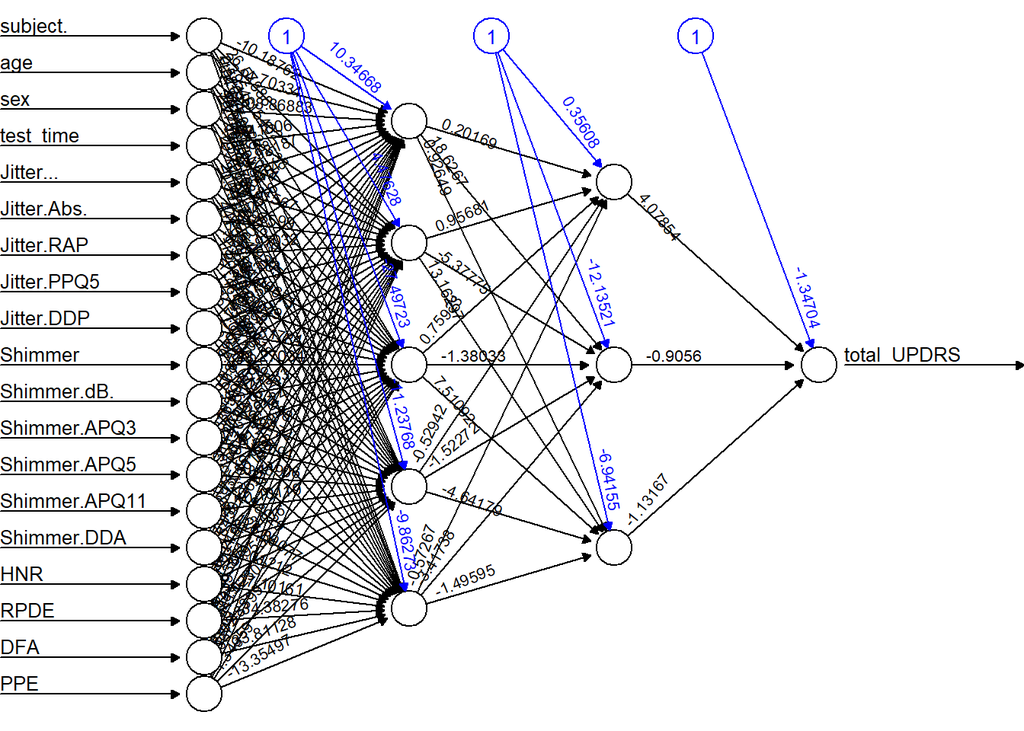

```r
plot(nn_fit_2,rep="best", cex=0.8)
```

Now we will fit the neural network with 1 hidden layer.

```r
nn_fit_1 <- neuralnet(f, data = train_scaled, hidden = 5, stepmax = 1e7)
```

#### Structure of the trained neural network with 1 hidden layer

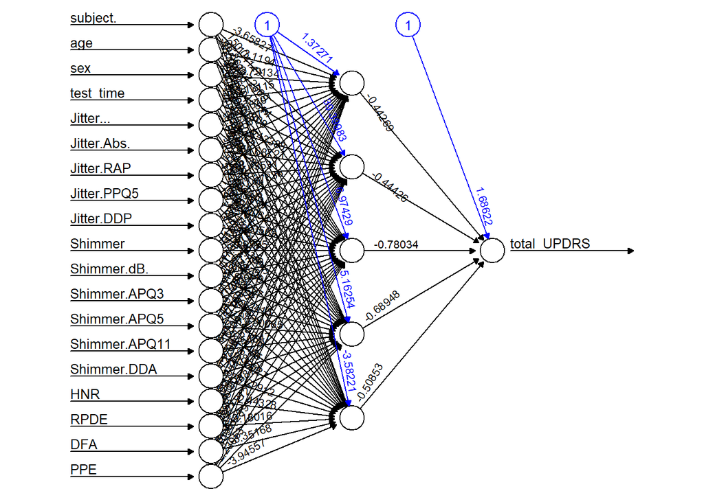

```r
plot(nn_fit_1, rep="best",cex=0.8)
```

# Evaluating Predictive Performance of the Two-Hidden-Layer Model

We are using compute method in the neural network package to do prediction of the test data.

```r
pred2_norm <- compute(nn_fit_2, test_scaled[-1])
pred2_norm <- pred2_norm$net.result
```

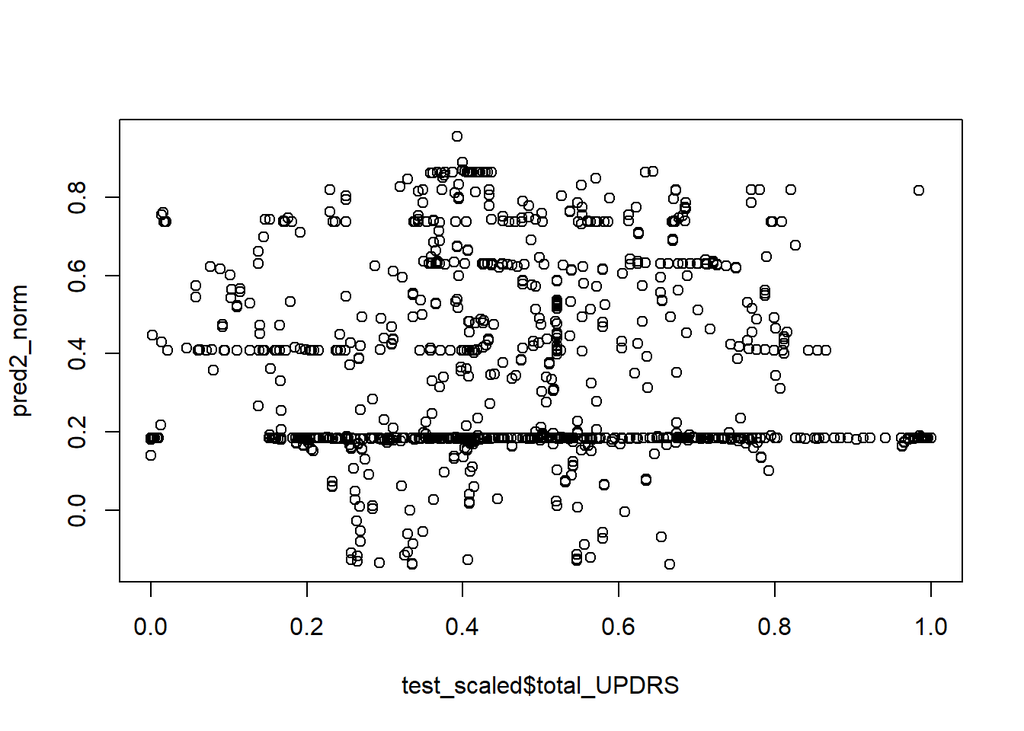

```r
plot(test_scaled$total_UPDRS,pred2_norm)
```

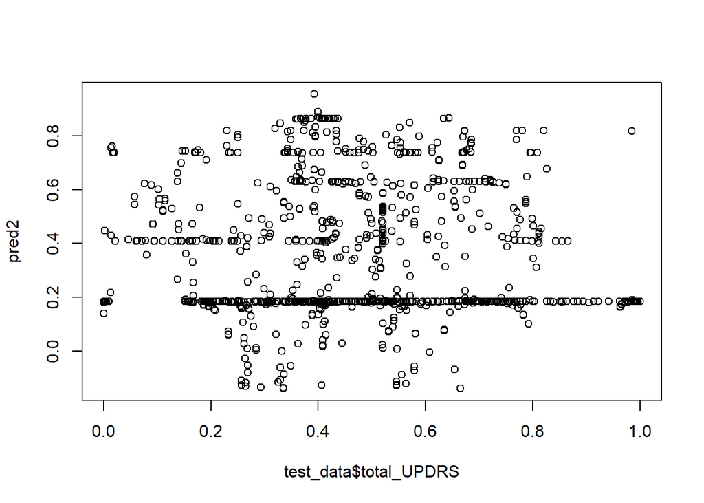

```r
pred2 <- pred2_norm*(max(train_data$total_UPDRS)-min(train_data$total_UPDRS))+ min(train_data$total_UPDRS)

plot(test_data$total_UPDRS,pred2)
```